# Parameter Estimation - Wild Fish Catch

Sydney Rilum

3/3/2021

### Introduction

In this document, nonlinear least squares will be utilized to estimate parameters for an equation that represents the increase in global wild fish catch from 1950 – 2012. Nonlinear least squares converges on parameter estimates that minimize the sum of squares of residuals through an iterative algorithm.

### Exploratory Graphs

```r
# Read in the data
fish_catch <- read_csv(here("data", "fish_catch.csv")) %>%
  row_to_names(row_number = 2) %>%  # convert second row to column headers
  clean_names() %>%
  slice(-(1:2), -(66:69)) %>%  # remove rows with notes/information
  mutate(years = 0:62) %>%  # create a new column numbering years starting at 0 (1950 = 0)
  mutate(wild_catch = as.numeric(wild_catch)) %>%
  mutate(year = as.numeric(year))
```

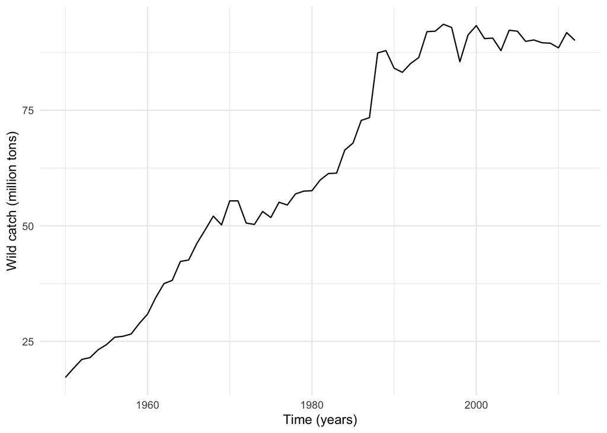

```r
# Exploratory graph
ggplot(data = fish_catch, aes(x = year, y = wild_catch)) +
  geom_line() +
  theme_minimal() +
  labs(x = "Time (years)",
       y = "Wild catch (million tons)")
```

**Figure 1.** Exploratory graph of world wild fish catch (in millions of tons) over time (in years) from 1950 – 2012. (Data: U.N. Food and Agriculture Organization (FAO))

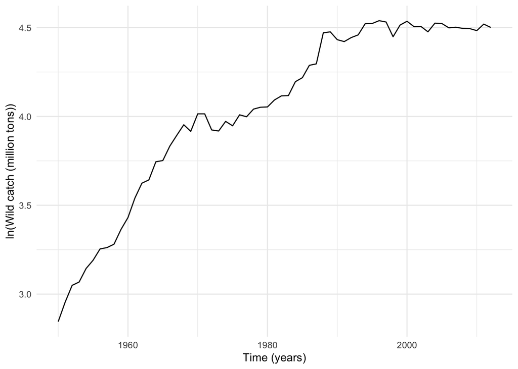

```r
# Exploratory graph of log transformed data
ggplot(data = fish_catch, aes(x = year, y = log(wild_catch))) +
  geom_line() +
  theme_minimal() +
  labs(x = "Time (years)",
       y = "ln(Wild catch (million tons))")
```

**Figure 2.** Exploratory graph of log transformed world wild fish catch (in millions of tons) over time (in years) from 1950 – 2012. (Data: U.N. FAO)

From the exploratory plots, there appears to be a logistic trend of wild fish catch over time. Wild fish catch increases exponentially until 1990 and then plateaus out, remaining relatively constant until 2012.

Mathematically, wild fish catch data can be described by the logistic growth equation:

$P(t)=\frac{K}{1+Ae^{-kt}}$, where

- $K$ is the carrying capacity
- $A$ is $\frac{K-P_0}{P_0}$
- $k$ is the growth rate constant

### Initial estimates for logistic growth parameters: *K*, *A* and *k*

```r
# Estimate the growth constant during exponential phase (to get a starting-point guess for *k*):
fish_catch_exp <- fish_catch %>%
  filter(years < 40) %>%  # Get only up to 40 years (exponential growth phase)
  mutate(ln_wild_catch = log(wild_catch))  # log transform the wild_catch data

# Model linear to get *k* estimate (the slope of this linear equation is an estimate of the growth rate constant):
lm_k <- lm(ln_wild_catch ~ years, data = fish_catch_exp)

# lm_k
# Coefficient (k) ~ 0.04
```

Initial estimates for model parameters:

- $K$ ~ 90
- $A$ ~ 4.23
- $k$ ~ 0.04

These estimates will be used as starting points for interactive algorithms used in nonlinear least squares that try to converge on the parameters.

### Find parameters for logistic model using nonlinear least squares

```r
# Enter model information, with a list of estimated starting parameter values:
fish_catch_nls <- nls(wild_catch ~ K/(1 + A*exp(-k*years)),
              data = fish_catch,
              start = list(K = 90, A = 4.23, k = 0.04),
              trace = FALSE)

# See the model summary (null hypothesis: parameter value = 0)
# summary(fish_catch_nls)

# Use broom:: functions to get model outputs in tidier format:
model_output <- broom::tidy(fish_catch_nls)
```

**Table 1.** Logistic model parameter estimates generated from nonlinear least squares, to be used to describe wild fish catch data.

```r
# Finalized table
model_output %>%
  gt() %>%
  fmt_number(columns = vars(estimate, std.error, statistic),
             decimals = 2) %>%
  fmt_scientific(columns = vars(p.value),
                 decimals = 2) %>%
  tab_options(table.width = pct(70),
              table.align = "left") %>%
  cols_label(term = "Term",
             estimate = "Estimate",
             std.error = "Standard Error",
             statistic = "Statistic",
             p.value = "p-value") %>%
  tab_header(title = "Parameter Estimates")%>%
  tab_footnote(footnote = "Units: K = million tons wild catch, A = unitless, k = million tons wild catch/year",
               locations = cells_column_labels(columns = vars(term)))
```

Parameter Estimates

| Term<sup>1</sup> | Estimate | Standard Error | Statistic | p-value |
| --- | --- | --- | --- | --- |
| K | 100.28 | 2.73 | 36.68 | 8.57 × 10<sup>−43</sup> |
| A | 4.32 | 0.29 | 14.73 | 1.34 × 10<sup>−21</sup> |
| k | 0.07 | 0.00 | 15.04 | 5.14 × 10<sup>−22</sup> |

<sup>*1*</sup> Units: K = million tons wild catch, A = unitless, k = million tons wild catch/year

The wild fish catch logistic model with estimated parameters can be written as:
$$P(t) = \frac{100.28}{1+4.32e^{-0.07t}}$$

### Visualize logistic model over original wild catch data

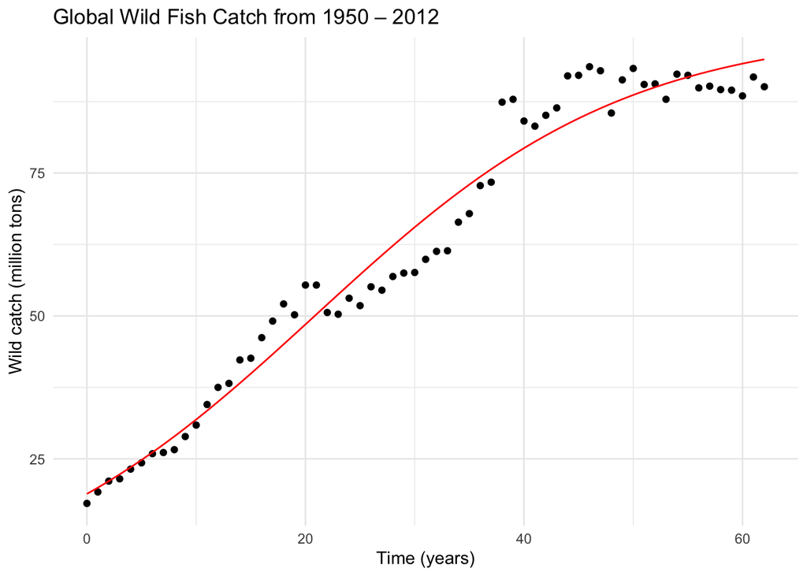

```r
# Make predictions of wild catch for each year in the original data frame
fish_catch_predict <- predict(fish_catch_nls)

# Bind predictions to original data frame
fish_catch_complete <- data.frame(fish_catch, fish_catch_predict)

# Plot original data and predicted values from model together:
ggplot(data = fish_catch_complete, aes(x = years, y = wild_catch)) +
  geom_point() +
  geom_line(aes(x = years, y = fish_catch_predict),
            color = "red") +
  theme_minimal() +
  labs(x = "Time (years)",
       y = "Wild catch (million tons)",
       title = "Global Wild Fish Catch from 1950 – 2012")
```

```r
# Find confidence intervals for parameter estimates
fish_catch_ci <- confint2(fish_catch_nls)
```

**Figure 3.** A plot displaying the logistic model output (red line) for wild fish catch over time in years against the original wild fish catch data (black points).

#### Citation:

Global wild fish catch and aquaculture production, compiled by Earth Policy Institute with 1950-2010 from U.N. Food and Agriculture Organization (FAO), Global Capture Production and Global Aquaculture Production, electronic databases.